User Manual

[figure not shown]

# User Manual - MultiStepTool

[figure not shown]

23. November 2021

- **User Interface Overview:**

  Gives a short overview of the UI.
- **Create a new Job:**

  Describes how to create new job for the
  - General Case
  - Special Case I
  - Special Case II
- **Create a Step Input File:**

  Describes how to create a new step input file.
- **Airdrag:**

  Describes how to load an airdrag component.

# User Interface Overview

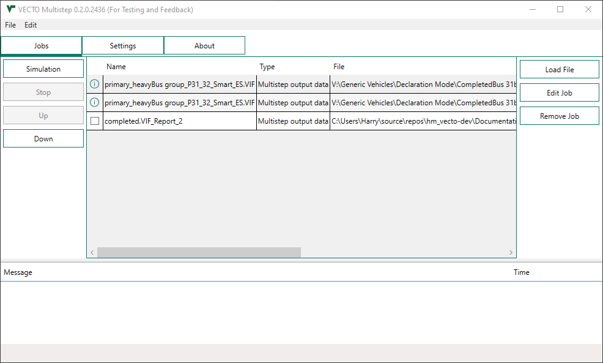

The main UI consists of three tabs, which are descriped in the following chapters

- **Jobs**  
  Add, simulate and edit jobs and input files.
- **Settings**  
  Simulation and GUI Settings.
- **About**  
  About VECTO.

## Jobs

The Jobs tab shows an overview of currently loaded jobs and allows the loading, editing and simulation of jobs. Note: Also jobs that cannot be edited with the GUI (i.e Primary Input Files), can be loaded and simulated.

[figure not shown]

### Simulation and Job Commands

#### Simulation:

Starts the simulation of all jobs that are marked for simulation. To mark a job for simulation, tick the checkbox in the left column of the job list. (see Start Simulation)

#### Stop:

Stops the current simulation, this operation can take some time and lead to error messages in the message view.

#### Up:

Moves the currently selected job up

#### Down:

Moves the currently selected job down

### Joblist

The joblist shows the name, type and file location of all currently loaded jobs and input files.

#### Adding Jobs

New jobs from existing files can be added to this list with the buttons in the File Section, Drag & Drop or using **File -> Load File**. New Jobs can be created using **File -> New File** (explained in more detail in the Create a new Job section).

#### Edit Jobs

A job can be edited by double clicking or using the **Edit Job** button in the File Section. It is also possible to show the source file of the currently selected job in the explorer or in the default editor using **Edit -> Source File -> Show in Explorer** or **Edit -> Source File -> Open in Editor**.

#### Start Simulation

By ticking the checkbox in the first column, a job is marked for simulation. When a job is simulated the jobfile is loaded again from the disk, therefore only saved changes are considered in the simulation.

If no simulation is possible, a small icon is displayed instead of the checkbox (as shown in the picture below). There are many reasons why a job cannot be simulated, clicking the icon shows additional information.

[figure not shown]

### File Section

- **Load File**: Load a new job from a .xml or .vecto file.
- **Edit**: Edit the selected job.
- **Remove**: Remove the selected job from the list.

### Messages

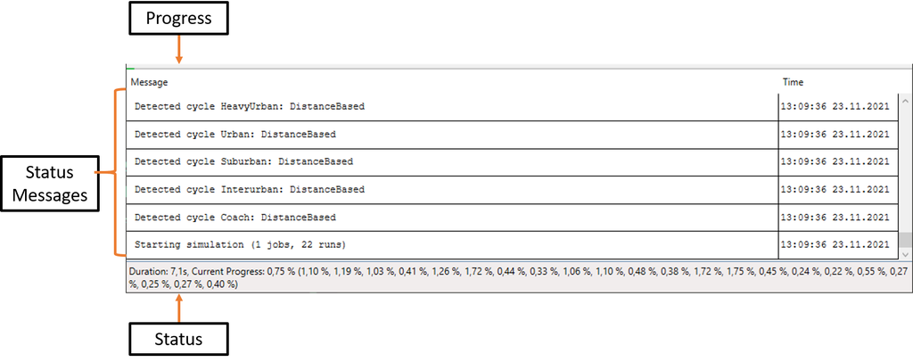

The message section display status messages from the simulation. Warnings are displayed in yellow, and errors in red. When a simulation is completed the result files can be displayed in an editor or in explorer.

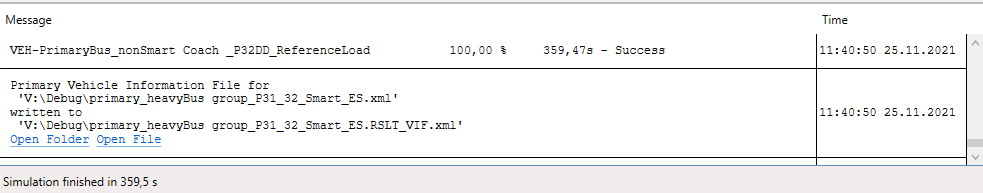

The progress bar on top shows the total simulation progress. The status bar shows the progress and duration of the total simulation and the progress of the individual simulation runs.

When running a chained simulation (Special Case I, Special Case II), it’s possible that another simulation is started automatically after the first step has completed, therefore the progress is not one hundred percent accurate.

## Settings

[figure not shown]

### 1 Default directories

#### Default input path

Specifies the initial directory for loading and saving files. Note: After loading or saving a file, the filedialog uses the last used directory as initial directory.

#### Default output path

Specifies the output directory for simulation results.

### 2 Simulation settings

Various simulation settings can be found here.

#### ModalResults1Hz

If selected, the modal results (.vmod file) will be converted into 1Hz after the simulation. This may add certain artefacts in the resulting modal results file.

#### Validate

Enables or disables internal checks if the model parameters are within a reasonable range. When simulating a new vehicle model it is good to have this option enabled. If the model parameters are from certified components or the model data has been modified slightly this check may be disabled. The VECTO simulation will abort anyways if there is an error in the model parameters. Enabling this option increases the simulation time by a few seconds.

#### Write Modal Results

Toggle output of modal results (.vmod files) in declaration mode. A Summary file (.vsum) is always created.

# Create a new Job

New jobs can be created via the file menu.

[figure not shown]

Three different types of jobs can be created with the multistep tool:

- **Interim/Completed Job**
- **Primary Job with Interim Input**
- **Complete Job**

They are described in more detail in the following chapters.

## New Interim/Completed Job - General Case

The general case is applicable to interim manufacturing steps and completed manufacturing steps. Required inputs in these steps are the VIF from the previous step and the input parameters of the current step. The latter can be entered via the graphical user interface.

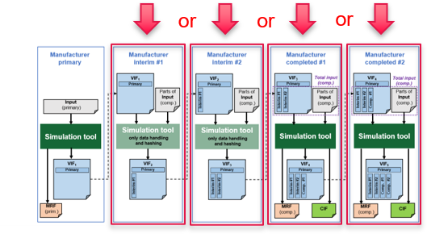

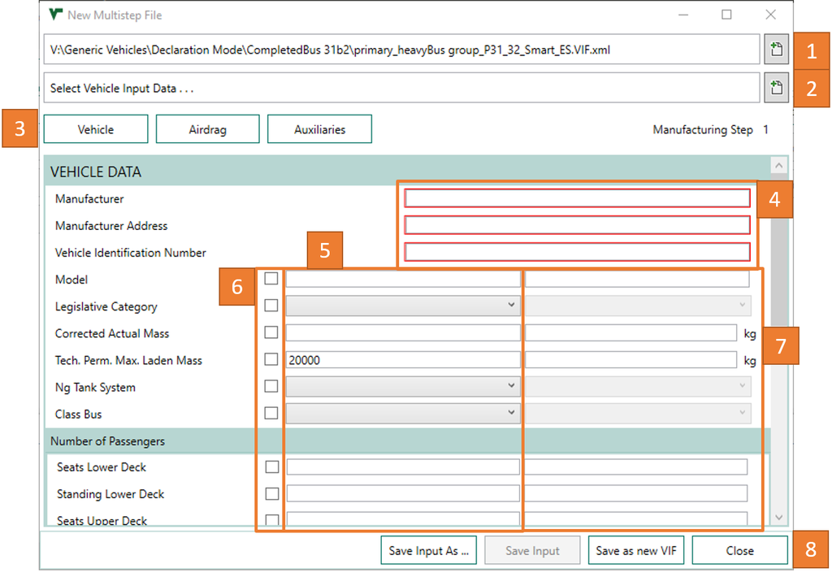

### 1 Load VIF from previous step

To create a VIF for the current step, the VIF from the previous step has to be loaded. After the VIF is loaded, the consolidated data from the previous steps is displayed and the input data for the current step can be added.

Note: It is also possible to directly add the VIF from the previous step to the job list.

### 2 Load input for current step (optional)

Instead of editing the input data for the current step manually, it is also possible to import previously saved input parameters. The input parameters can be saved during the creation of a VIF (see Save and Close) or can be created using **File -> New File -> Create Interim/Completed Input** (see Create a step input file).

### 3 The input data is split into three components.

- **Vehicle** Contains the main vehicle parameters (manufacturer, model, masses, seats, dimensions, ADAS etc.)
- **Airdrag** Allows the loading of an airdrag component file, and displays the consolidated airdrag data from the previous steps. For more information see Airdrag
- **Auxiliaries** Contains the paremeters concering auxiliaries (HVAC, LED-Lights etc.).

### 6 Enable editing

To edit a parameter in the current step, the editing has to be enabled by checking the corresponding checkbox. A special case is editing the input parameters that have to be provided as a group (i.e., dimensions, passenger count, ADAS). If the editing for one parameter of this group is enabled, all parameters from the group need to be provided.

### 7 Current step input Data

In this column the input data of the current step is displayed, and can be edited. The entries are checked with regard to the data type. The entered data is available and can be edited as long as VECTO wasn’t closed and the job wasn’t removed from the job list. In case a mandatory input field is empty, or the value provided by the user is invalid the input element is highlighted with a red border. To remove an entry from the current step uncheck the corresponding checkbox.

### 8 Save and Close

- **Save Input As …**:  
  Saves the input of the current step to a new file.
- **Save Input**:  
  Saves the input of the current step to the loaded input file.
- **Save as new VIF**:  
  creates a new VIF and adds it to the job list. If ‘Vehicle Declaration Type’ is set to ‘Final’ and all required parameters are present, the file can directly be simulated.
- **Close**:  
  Closes the window. Note: As long as VECTO is open and the job is not removed from the job list, unsaved changes remain in the job for further editing.

## New Primary Job with Interim Input - Special Case I

If the manufacturer of the primary vehicle also adds certain components of the completed step (e.g., HVAC compressor), it is required that the VIF created at the primary step already contains the provided input parameters of the completed step. Therefore, at the primary step the input consists on the one hand of the input XML for the primary vehicle and on the other hand the XML with parts of the completed vehicle.

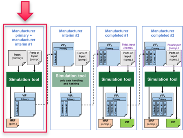

To create primary job with interim input create new job with **File -> New File -> New Primary Job with Interim Input** The job is automatically added to the job list for further editing, but simulation is only possible when the job is saved.

[figure not shown]

### 1 Load primary input file

In the first simulation step the primary input is simulated and an intermediate VIF and a MRF are created. The step input is then added and the resulting VIF is written to disk.

### 2 Select step input file

Select the step input that should be applied in the first manufacturing step.

Note: If an exempted primary input is loaded, the step input has also be for an exempted vehicle.

### 3 Save and Close

After saving the file the job can be simulated.

Note: If the applied step input is completed and marked as “final”, VECTO automatically starts the simulation (as in Special Case II).

## New Complete Job - Special Case II

If a bus is produced and homologated in a single step (“complete”) it is required that the simulation of the whole vehicle is done in one VECTO invocation, applying the factor method. VECTO in this case creates the MRF of the primary step, the MRF of the completed step, the VIF of the first manufacturing step with the complete vehicle information, and the CIF. Thus, the input consists of both, the input XML for the primary vehicle and the XML with all parameters of the completed vehicle.

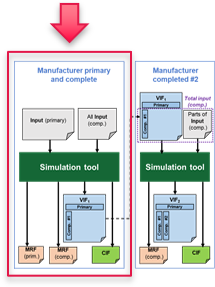

To create a job for Special Case II, select **File -> New File -> New Complete Job**, the further steps are identical to Special Case I.

Note: If the VIF resulting from the primary input and the step input, cannot be simulated, add the resulting VIF to the job list and click the info icon to get additional information.

# Create a step input file

As mentioned before it is possible to load step input files when creating new jobs. Apart from saving the step input while creating a VIF, there is also the possibility to create the step input without a VIF.

To create a new step input file select **File -> New File -> Create Interim/Completed Input**.

[figure not shown]

It is possible to create input files for

- Non exempted vehicles
- Exempted vehicles

## Non exempted step input

When creating a new step input, it is automatically added to the job list for further editing.

[figure not shown]

### 2 Enable editing

To edit an optional parameter, this checkbox has to be ticked.

### 3 Parameters for step input

In this column the input data of the current step is displayed, and can be edited. The entries are checked with regard to the data type. The entered data is available and can be edited as long as VECTO wasn’t closed and the job wasn’t removed from the job list. In case a mandatory input field is empty, or the value provided by the user is invalid the input element is highlighted with a red border. To remove an entry from the current step uncheck the corresponding checkbox.

### 4 Save and Close

Save the input data to .xml, the data will still be editable via the job list as long as Vecto was not closed and the file was not removed from the joblist.

## Exempted step input

The process for creating an exempted step input are the same as for non exempted input files.

# Airdrag

In the **Airdrag** section the consolidated airdrag data is shown and an airdrag component file can be loaded as input for the current step.

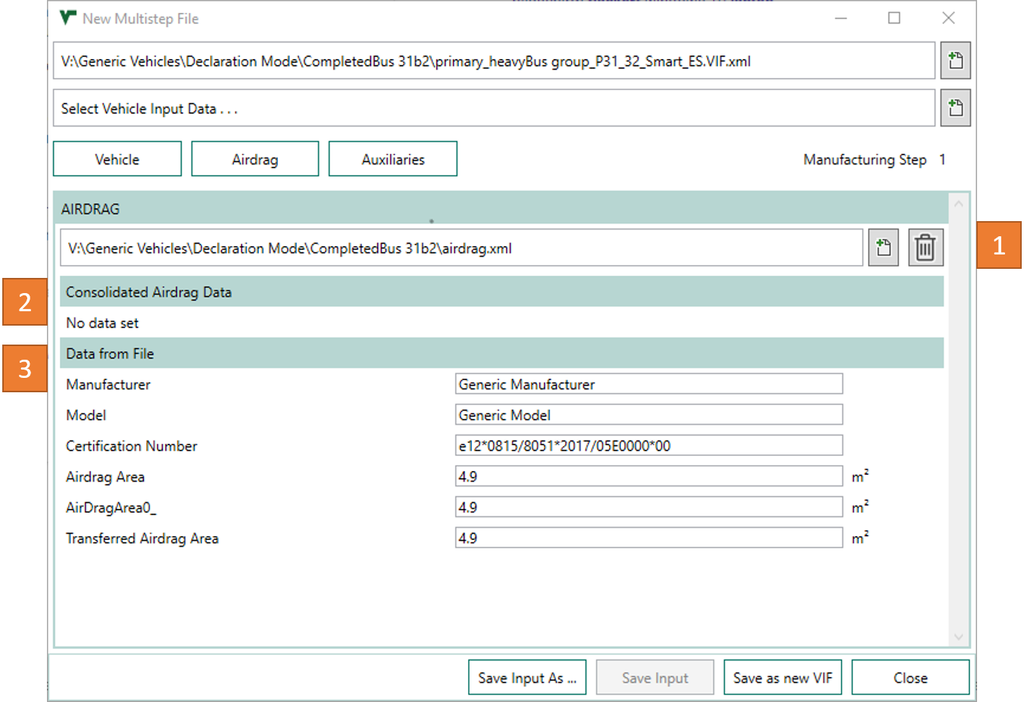

**1 Load Airdrag Component File** To set the airdrag component for the current step, it has to be loaded from an existing airdrag component file. To remove the data from the current step, click the trash icon.

**2 Consolidated Airdrag Data** In this section the consolidated airdrag data from the previous manufacturing steps is displayed.

**3 Current Step Airdrag Data** In this section the airdrag data from the current step is displayed, the values cannot be edited directly in the GUI.

Contrary to all other components, for air drag it is defined that in case standard values shall be used for a particular vehicle, no component input data shall be provided. In this case VECTO automatically allocates the standard values applicable for the particular vehicle group in the simulations. Assuming an interim manufacturer mounts the body of the complete bus and provides measured air-drag data, this is written to the VIF. In case the body is modified in a later manufacturing step in such a way that the measured air-drag data is no longer applicable but no updated measurement data is available the standard value has to be applied. (learn more in Airdrag Modified Multistep).

## Airdrag Modified Multistep

When airdrag data has been provided in any previous simulation step the **Airdrag Modified Multistage** parameter can be set in the *Vehicle* section, if no airdrag data has been provided in previous steps this parameter is hidden.

All manufacturing steps after the one where the air-drag component was added need to state whether modifications have been made that affect the air-drag.

- In case no modifications were made, “AirdragModifiedMultistep” has to be set to false and the previous air-drag component is used.
- In case modifications were made, “AirdragModifiedMultistep” has to be set to true. The interim manufacturer can provide a new measured air-drag component to be used for the simulation. In case no updated measurement is provided VECTO applies the standard values. In the VIF this is indicated by using a special XML type for the air-drag component.